# My Spotify Wrapped

Kaiqi Chen

## The data

- My yearly Spotify Wrapped from 2016-2019, include audio features and track popularity.
- My saved songs in Spotify, include audio features, track and artist popularity, and whether they are in my Wrapped playlists

## Visualize My Spotify Wrapped 2016-2019

It seems I listen to slightly more higher energy songs in 2018.

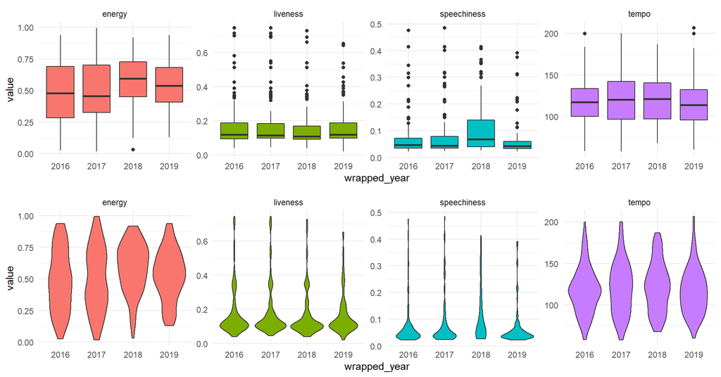

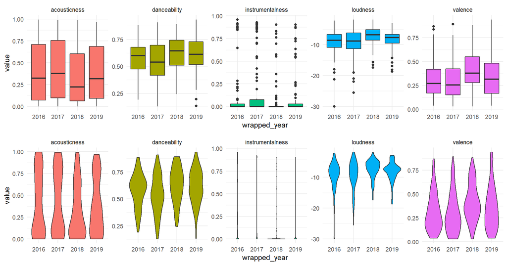

## Track Popularity

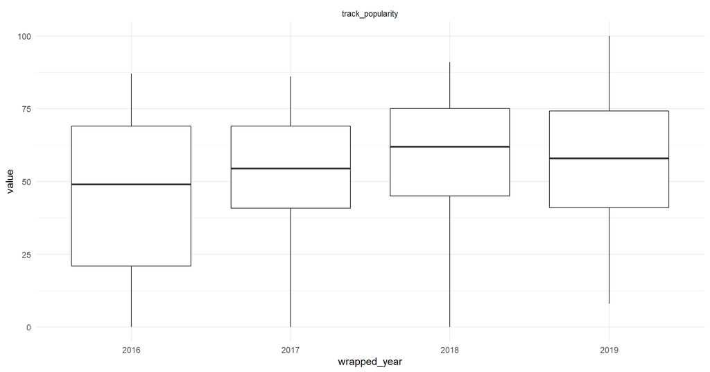

Track popularity remains about the same each year. A good portion of them are on the popular side in 2017, 2018, 2019.

Overall, no visualy huge changes in preference.

## It’s very tempting to do ANOVA test, but

```
##
##      Balanced one-way analysis of variance power calculation
##
##               k = 4
##               n = 273.5429
##               f = 0.1
##       sig.level = 0.05
##           power = 0.8
##
## NOTE: n is number in each group
```

For a small effect size, we need 274 songs for each year.

## Build a model

I wonder if I can build a model to determine whether a song I saved to my library will become one of my top song at the end of the year.

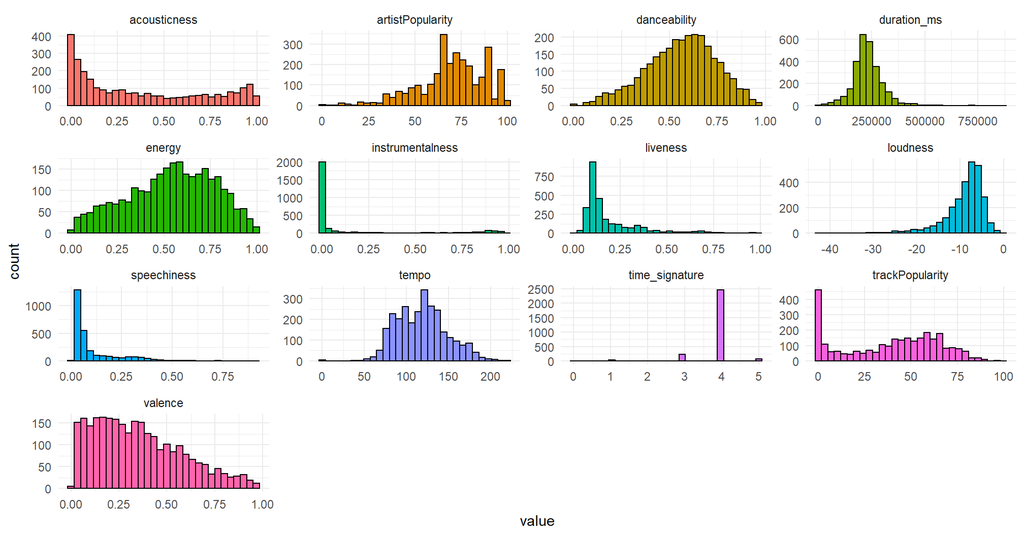

Duration, instrumentalness, liveness, speechiness and time_signature are probably not very useful.

## Categorical Variables

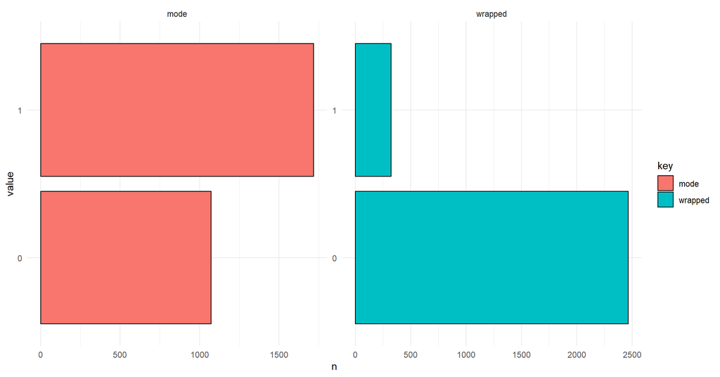

The dependent variable is very imbalanced.

## Correlations

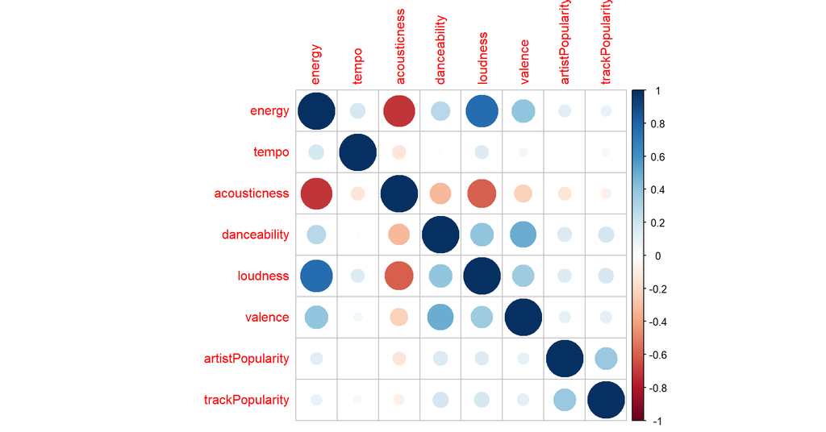

Drop loudness, acousticness, and valence

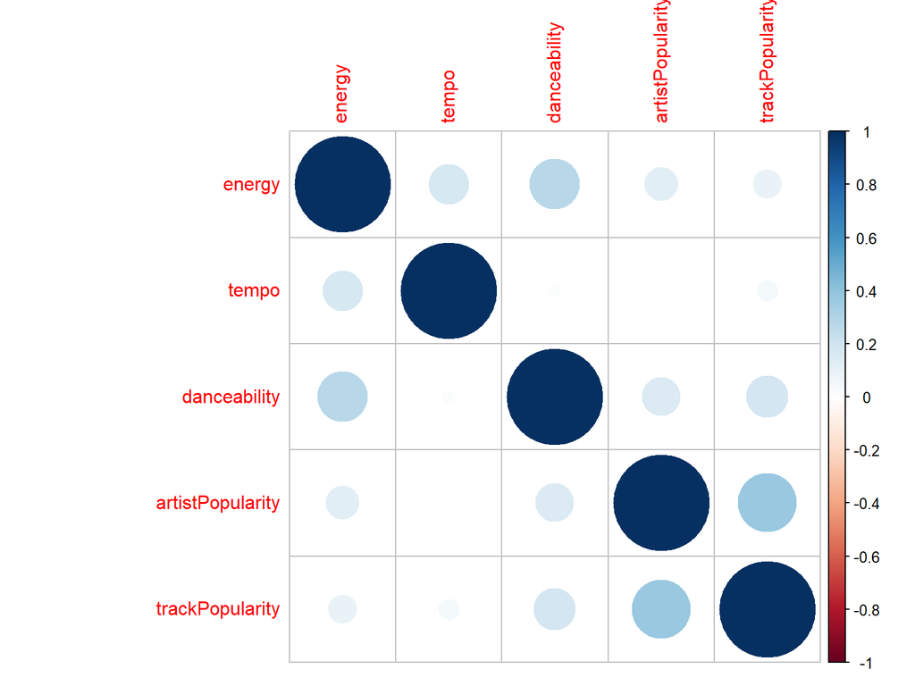

Since my data is imbalanced, balace it before running models.

## Bivariate relationships

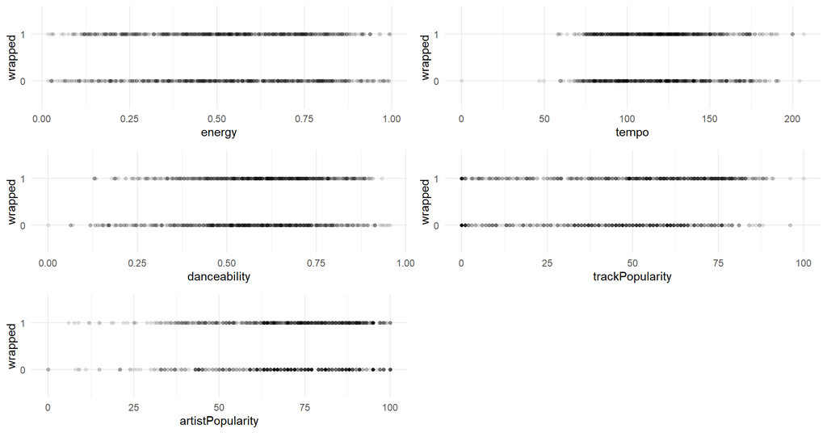

```
##
## Call:
## glm(formula = wrapped ~ tempo + energy + danceability + artistPopularity +
##     trackPopularity, family = binomial(link = "logit"), data = songs_balance)
##
## Deviance Residuals:
##    Min      1Q  Median      3Q     Max
## -1.732  -1.133   0.112   1.080   1.838
##
## Coefficients:
##                   Estimate Std. Error z value Pr(>|z|)
## (Intercept)      -0.602663   0.361853  -1.665  0.09581 .
## tempo             0.002116   0.002088   1.014  0.31081
## energy           -0.724013   0.278145  -2.603  0.00924 **
## danceability      1.096513   0.356197   3.078  0.00208 **
## artistPopularity -0.015104   0.003705  -4.077 4.56e-05 ***
## trackPopularity   0.025130   0.002835   8.866  < 2e-16 ***
## ---
## Signif. codes:  0 '***' 0.001 '**' 0.01 '*' 0.05 '.' 0.1 ' ' 1
##
## (Dispersion parameter for binomial family taken to be 1)
##
##     Null deviance: 1802.2  on 1299  degrees of freedom
## Residual deviance: 1691.4  on 1294  degrees of freedom
## AIC: 1703.4
##
## Number of Fisher Scoring iterations: 4
```

Tempo is not a significant variable, remove it.

```
##
## Call:
## glm(formula = wrapped ~ energy + danceability + artistPopularity +
##     trackPopularity, family = binomial(link = "logit"), data = songs_balance)
##
## Deviance Residuals:
##      Min        1Q    Median        3Q       Max
## -1.70821  -1.13831   0.08452   1.07199   1.86696
##
## Coefficients:
##                   Estimate Std. Error z value Pr(>|z|)
## (Intercept)      -0.377399   0.284939  -1.324  0.18534
## energy           -0.654329   0.269344  -2.429  0.01513 *
## danceability      1.081229   0.355583   3.041  0.00236 **
## artistPopularity -0.015194   0.003703  -4.103 4.07e-05 ***
## trackPopularity   0.025224   0.002834   8.902  < 2e-16 ***
## ---
## Signif. codes:  0 '***' 0.001 '**' 0.01 '*' 0.05 '.' 0.1 ' ' 1
##
## (Dispersion parameter for binomial family taken to be 1)
##
##     Null deviance: 1802.2  on 1299  degrees of freedom
## Residual deviance: 1692.5  on 1295  degrees of freedom
## AIC: 1702.5
##
## Number of Fisher Scoring iterations: 4
```

```
##      (Intercept)           energy     danceability artistPopularity
##        0.6856423        0.5197909        2.9483013        0.9849207
##  trackPopularity
##        1.0255452
```

## Machine learning approach to evaluate the performance

```
##
## Call:
## glm(formula = wrapped ~ energy + danceability + artistPopularity +
##     trackPopularity, family = binomial(link = "logit"), data = songs.train)
##
## Deviance Residuals:
##     Min       1Q   Median       3Q      Max
## -1.8027  -1.1464   0.0625   1.0563   1.9090
##
## Coefficients:
##                   Estimate Std. Error z value Pr(>|z|)
## (Intercept)      -0.500920   0.291792  -1.717 0.086034 .
## energy           -0.588408   0.263438  -2.234 0.025511 *
## danceability      0.942511   0.356051   2.647 0.008118 **
## artistPopularity -0.014555   0.003787  -3.844 0.000121 ***
## trackPopularity   0.028588   0.002758  10.367  < 2e-16 ***
## ---
## Signif. codes:  0 '***' 0.001 '**' 0.01 '*' 0.05 '.' 0.1 ' ' 1
##
## (Dispersion parameter for binomial family taken to be 1)
##
##     Null deviance: 1802.2  on 1299  degrees of freedom
## Residual deviance: 1659.9  on 1295  degrees of freedom
## AIC: 1669.9
##
## Number of Fisher Scoring iterations: 4
```

[output not shown]

## Ideal cutoff

```
## [1] 0.5253408
```

## Evaluate Performance

```
## Confusion Matrix and Statistics
##
##           Reference
## Prediction   0   1
##          0 372  31
##          1 244  50
##
##                Accuracy : 0.6055
##                  95% CI : (0.5681, 0.6419)
##     No Information Rate : 0.8838
##     P-Value [Acc > NIR] : 1
##
##                   Kappa : 0.1033
##
##  Mcnemar's Test P-Value : <2e-16
##
##             Sensitivity : 0.61728
##             Specificity : 0.60390
##          Pos Pred Value : 0.17007
##          Neg Pred Value : 0.92308
##              Prevalence : 0.11621
##          Detection Rate : 0.07174
##    Detection Prevalence : 0.42181
##       Balanced Accuracy : 0.61059
##
##        'Positive' Class : 1
##
```

```
## [1] 0.6054519
```

```
## [1] 0.1032623
```

## Bayesian Logistic Regression

```
##
## Model Info:
##  function:     stan_glm
##  family:       binomial [logit]
##  formula:      wrapped ~ energy + danceability + artistPopularity + trackPopularity
##  algorithm:    sampling
##  sample:       12000 (posterior sample size)
##  priors:       see help('prior_summary')
##  observations: 1300
##  predictors:   5
##
## Estimates:
##                    mean   sd   10%   50%   90%
## (Intercept)      -0.4    0.3 -0.7  -0.4   0.0
## energy           -0.7    0.3 -1.0  -0.7  -0.3
## danceability      1.1    0.4  0.6   1.1   1.5
## artistPopularity  0.0    0.0  0.0   0.0   0.0
## trackPopularity   0.0    0.0  0.0   0.0   0.0
##
## Fit Diagnostics:
##            mean   sd   10%   50%   90%
## mean_PPD 0.5    0.0  0.5   0.5   0.5
##
## The mean_ppd is the sample average posterior predictive distribution of the outcome variable (for details see help('summary.stanreg')).
##
## MCMC diagnostics
##                  mcse Rhat n_eff
## (Intercept)      0.0  1.0  16863
## energy           0.0  1.0  12959
## danceability     0.0  1.0  13688
## artistPopularity 0.0  1.0  11950
## trackPopularity  0.0  1.0  11627
## mean_PPD         0.0  1.0  12428
## log-posterior    0.0  1.0   5588
##
## For each parameter, mcse is Monte Carlo standard error, n_eff is a crude measure of effective sample size, and Rhat is the potential scale reduction factor on split chains (at convergence Rhat=1).
```

## Posterior intervals:

```
##                         2.5%        97.5%
## energy           -1.19478122 -0.112840644
## danceability      0.40998222  1.790827063
## artistPopularity -0.02264516 -0.008090892
## trackPopularity   0.01982764  0.030861793
```

## More to do

1. Bootstrapping on GLM, compare CIs with Bayesian CIs.
2. Improve both accuracy and fututure performance.
3. Mixed model or interactions are worth exploring, but require more data
4. Gather other users data, and see how the models differ.
5. Build something that can generalize to different users of Spotify